# Modelagem do sequenciamento genético a partir de uma cadeia de Markov

Gustavo Almeida Silva

19/07/2022

## Parte 1: Cadeia de Markov, aplicação no sequenciamento genetico

A cadeia de Markov é um processo estocástcio que busca estimar probabibilidades de transição entre estados, e que tem como sua sua pricial propriedade a chamada memoria Markoviana. Para calcularmos tais transições temos a chamda matriz de transição de probabilidade, onde essa indica a probabilidade de transsição entre cada estado do processo. Essa matriz possuir propriedades importantíssima, onde utilizaremos delas nesse estudo * Propriedade da memoria Markoviana + Diz respeito à estrutura condicional do processo, dado que estamos em um tempo $T_k$, a probabilidade de transição entre os estados do processo depende apenas do que ocorreu em $T_{k-1}$

- Equação de Chapman-Komolgorov
  - Com uma matriz de transição, sabemos as probabilidades de transição no tempo $T_k$, porem atraves da equaçaõ de Chapman-Komolgorov, podemos estimar a matriz de transição em qualquer $T_{k+x}$
- Probabilidade limites
  - Como consequencia direta da equação de Chapman-Komolgorov, se deserjamos estimar a matriz em um $\lim_{x \to \infty} T_{k+x}$, estaremos estimando as probabilidades limites da matriz, onde cada coluna possui um valor de convergencia igual

Cadeias de Markov possuem um amplo campo utilização, e nesse estudo buscaremos estimar as probabilidades de transição em uma seqeuncia genetica. Para isso, dado uma amostra de DNA, iremos estimar sua matriz de probabilidade e suas probabilidades limites. Como curiosidade, iremos observar qual distribuiçao cada estado segue, com amostrar obitdas atraves de uma simulação de uma simulação MOnte Carlo

## Parte 2: Obtenção dos dados e desenvolvimento das funçoes

- Propriedade de falta de memória
  - Diz respeito à estrutura condicional do processo, onde a probabilidade de ocorrer alguma observação entre os tempos $T_1$ e $T_2$ é independente do número de observações registradas entre $T_0$ e $T_1$
- Propriedade do Tempo de Chegada: distribuição e independência
  - O intervalo de tempo entre a chegada de 2 observações seguem uma distribuição Exponencial, onde por conta do processo possuir a propriedade de falta de memória, esses $T_i$ são IID. Assim, a soma de tempos de chegada segue uma Gama

```r
#Using https://www.bioinformatics.org/sms2/random_dna.html website as DNA generator

DNA=c("ccctatagtctatagcttctcgtctatagttaagattcgtacgcatctggagtgttggcg…")
DNA=strsplit(DNA, split = "")
DNA=DNA[[1]]
```

```r
## ---------------Among of function that returns the proportion of the nucleotides---------

#1
proportion=function(data_dna,word1,word2){
  counts=0
  total=0


  for(i in 1:(length(data_dna)-1)){
    if(data_dna[i]==word1)
      {
      total=total+1
    if(data_dna[i+1]==word2)
      counts=counts+1
    }
  }
  return(counts/total)
}


#2
##The factors levels are organize by the alphabetic sequence
nucleo_finder=function(data_dna){
  data_dna=levels(factor(data_dna))
  return(data_dna)
}

#3 final
nucleo_prob_matrix=function(data_dna){
  nucleotides=nucleo_finder(data_dna)
  nucleo_matrix=matrix(rep(0,length(nucleotides)**2),byrow = T,nrow=4)

  for(j in 1:length(nucleotides))
    for(i in 1:length(nucleotides)){
      nucleo_matrix[j,i]=proportion(data_dna,nucleotides[j],nucleotides[i])
    }


return(nucleo_matrix)


}

#-------Among of functions that returns the stationary distribution  dna´s markov chain (Solving via eigendecomposition)
stationary <- function(transition) {
  stopifnot(is.matrix(transition) &&
        nrow(transition)==ncol(transition) &&
            all(transition>=0 & transition<=1))
  p <- diag(nrow(transition)) - transition
  A <- rbind(t(p),
         rep(1, ncol(transition)))
  b <- c(rep(0, nrow(transition)),
         1)
  res <- qr.solve(A, b)
  names(res) <- paste0("state.", 1:nrow(transition))
  return(res)
}

##Transition probability matrix
nucleo_prob_matrix(DNA)
```

```
##           [,1]      [,2]      [,3]      [,4]
## [1,] 0.2427984 0.1646091 0.2757202 0.3168724
## [2,] 0.2327586 0.2370690 0.2543103 0.2758621
## [3,] 0.2579365 0.2579365 0.2460317 0.2380952
## [4,] 0.2426471 0.2610294 0.2352941 0.2610294
```

```r
##Stationary states
stationary(nucleo_prob_matrix(DNA))
```

```
##   state.1   state.2   state.3   state.4
## 0.2442553 0.2311593 0.2522730 0.2723124
```

## Simulation of the markov chain. Checking the stationary states

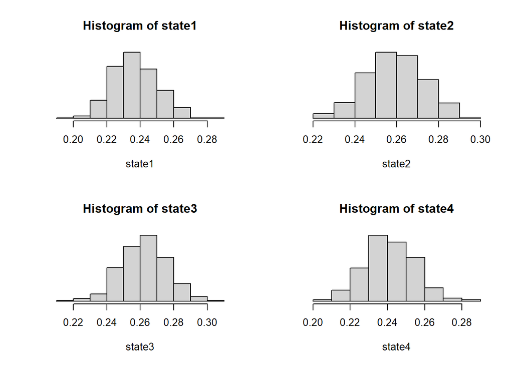

```r
dna_manipulation=function(DNA){
  DNA=strsplit(DNA, split = "")
  DNA=DNA[[1]]
}

database_dna=
      list('tcaggaattcgcctgccagggtactatgcctccctagaaaatacgagacgttgctaatag…','tcaggaattcgcctgccagggtactatgcctccctagaaaatacgagacgttgctaatag…','cttcactgatactggacggagtatgaaccattttccacgggacagccgcttaataatttg…','atcaatgggtggcggtggcggcaacggttggaccaaaagggtcaggggcgggggcaaatc…')

# dna_simulation=function(database_dna){

    database_dna=lapply(database_dna,dna_manipulation)

    for(k in 1:500){
        teste=vector()
        i=1
        while(length(teste)<=1000){
          if(i>3+k)
                i=1
          random=runif(1,min=1,max=1000)
          teste=c(teste,database_dna[[i]][random])
          i=i+1
        }

      teste=list(teste)
      database_dna=c(database_dna,teste)
    }

# }







database_dna=lapply(database_dna,nucleo_prob_matrix)
database_dna=lapply(database_dna,stationary)

state1=sapply(1:length(database_dna),function(i)database_dna[[i]][1])
state2=sapply(1:length(database_dna),function(i)database_dna[[i]][2])
state3=sapply(1:length(database_dna),function(i)database_dna[[i]][3])
state4=sapply(1:length(database_dna),function(i)database_dna[[i]][4])

par(mfrow=c(2,2))
hist(state1,freq=F,ylab="",yaxt="n")
hist(state2,freq=F,ylab="",yaxt="n")
hist(state3,freq=F,ylab="",yaxt="n")
hist(state4,freq=F,ylab="",yaxt="n")
```